# Bike Share Analysis Report

Santanu Jha

12/10/2023

## Business Question Task & Background

Launched in 2016, Cyclistic is a successful point-to-point bike-share program consisting of 5,824 geo-tracked bicycles and 692 locking stations across Chicago.

Historically, Cyclistic’s marketing strategy has focused on increasing public awareness and appealing to a broad market.

Cyclistic’s business objective is to understand the differences in how annual members and casual riders utilize their bikes. The goal is to analyze and identify distinct patterns and behaviors between these two user groups. This information can help optimize services, tailor marketing strategies, and enhance the overall user experience for each segment.

## Data Source

You will use Cyclistic’s historical trip data to analyze and identify trends. Download the Cyclistic trip data here.

For the purposes of this case study, the datasets are appropriate and will enable you to answer the business questions. The data has been made available by Motivate International Inc. under this license.

## Data Cleaning and Manipulation

The following steps were performed to prepare the data for analysis:

- Data loading and package installation
- Parsing date and time columns
- Creating additional columns for analysis (e.g., time of day, trip duration category)
- Handling missing values and filtering out invalid trip durations

Before Cleaning and Manipulation:

```r
summary(my_df)
```

```
##    ride_id          rideable_type       started_at          ended_at
##  Length:1048575     Length:1048575     Length:1048575     Length:1048575
##  Class :character   Class :character   Class :character   Class :character
##  Mode  :character   Mode  :character   Mode  :character   Mode  :character
##
##
##
##
##  start_station_name start_station_id   end_station_name   end_station_id
##  Length:1048575     Length:1048575     Length:1048575     Length:1048575
##  Class :character   Class :character   Class :character   Class :character
##  Mode  :character   Mode  :character   Mode  :character   Mode  :character
##
##
##
##
##    start_lat       start_lng         end_lat         end_lng
##  Min.   :41.65   Min.   :-87.84   Min.   :41.63   Min.   :-88.11
##  1st Qu.:41.88   1st Qu.:-87.66   1st Qu.:41.88   1st Qu.:-87.66
##  Median :41.90   Median :-87.64   Median :41.90   Median :-87.64
##  Mean   :41.90   Mean   :-87.65   Mean   :41.90   Mean   :-87.65
##  3rd Qu.:41.93   3rd Qu.:-87.63   3rd Qu.:41.93   3rd Qu.:-87.63
##  Max.   :42.07   Max.   :-87.52   Max.   :42.08   Max.   :-87.52
##                                   NA's   :989     NA's   :989
##  member_casual
##  Length:1048575
##  Class :character
##  Mode  :character
##
##
##
##
```

```r
my_df <- my_df %>%
  mutate(
    started_at = as.POSIXct(started_at, format = "%m/%d/%Y %H:%M"),
    ended_at = as.POSIXct(ended_at, format = "%m/%d/%Y %H:%M"),
    start_hour = hour(started_at),
    time_of_day = case_when(
      start_hour >= 5 & start_hour < 12 ~ "morning",
      start_hour >= 12 & start_hour < 17 ~ "afternoon",
      TRUE ~ "evening"
    ),
    start_time = format(started_at, "%H:%M:%S"),
    end_time = format(ended_at, "%H:%M:%S"),
    trip_duration = as.numeric(difftime(ended_at, started_at, units = "mins")),
    month = format(started_at, "%B"),
    weekday = format(started_at, "%A"),
    route = paste(start_station_name, "to", end_station_name)
  )

my_df$trip_duration <- as.numeric(as.character(my_df$trip_duration))
my_df <- my_df %>%
  mutate(
    trip_duration_category = cut(
      trip_duration,
      breaks = c(0, 15, 30, Inf),
      labels = c("Short", "Medium", "Long"),
      include.lowest = TRUE
    )
  )

# Check for total number of missing/null values
total_na_values <- sum(is.na(my_df))

# Delete all null/missing and 0 values and store it in a new dataframe my_data
my_data <- my_df %>%
  drop_na() %>%
  filter(!is.na(trip_duration) & trip_duration > 0)
```

After Cleaning and Manipulation:

```r
# Ready Data for Analysis
summary(my_data)
```

```
##    ride_id          rideable_type        started_at
##  Length:768939      Length:768939      Min.   :2022-12-01 00:01:00.00
##  Class :character   Class :character   1st Qu.:2023-01-12 07:06:00.00
##  Mode  :character   Mode  :character   Median :2023-02-20 19:58:00.00
##                                        Mean   :2023-02-17 05:17:20.25
##                                        3rd Qu.:2023-03-25 11:48:00.00
##                                        Max.   :2023-04-30 23:57:00.00
##     ended_at                      start_station_name start_station_id
##  Min.   :2022-12-01 00:03:00.00   Length:768939      Length:768939
##  1st Qu.:2023-01-12 07:16:00.00   Class :character   Class :character
##  Median :2023-02-20 20:10:00.00   Mode  :character   Mode  :character
##  Mean   :2023-02-17 05:29:51.66
##  3rd Qu.:2023-03-25 12:00:00.00
##  Max.   :2023-05-01 07:11:00.00
##  end_station_name   end_station_id       start_lat       start_lng
##  Length:768939      Length:768939      Min.   :41.65   Min.   :-87.83
##  Class :character   Class :character   1st Qu.:41.88   1st Qu.:-87.66
##  Mode  :character   Mode  :character   Median :41.89   Median :-87.64
##                                        Mean   :41.90   Mean   :-87.65
##                                        3rd Qu.:41.93   3rd Qu.:-87.63
##                                        Max.   :42.06   Max.   :-87.53
##     end_lat         end_lng       member_casual        start_hour
##  Min.   :41.65   Min.   :-87.83   Length:768939      Min.   : 0.00
##  1st Qu.:41.88   1st Qu.:-87.66   Class :character   1st Qu.:10.00
##  Median :41.89   Median :-87.64   Mode  :character   Median :15.00
##  Mean   :41.90   Mean   :-87.65                      Mean   :13.73
##  3rd Qu.:41.93   3rd Qu.:-87.63                      3rd Qu.:17.00
##  Max.   :42.06   Max.   :-87.53                      Max.   :23.00
##  time_of_day         start_time          end_time         trip_duration
##  Length:768939      Length:768939      Length:768939      Min.   :   1.00
##  Class :character   Class :character   Class :character   1st Qu.:   5.00
##  Mode  :character   Mode  :character   Mode  :character   Median :   8.00
##                                                           Mean   :  12.52
##                                                           3rd Qu.:  14.00
##                                                           Max.   :1498.00
##     month             weekday             route
##  Length:768939      Length:768939      Length:768939
##  Class :character   Class :character   Class :character
##  Mode  :character   Mode  :character   Mode  :character
##
##
##
##  trip_duration_category
##  Short :610859
##  Medium:112976
##  Long  : 45104
##
##
##
```

## **Analysis**

#### **Distribution of Member Types Based on Trip Duration**

- Utilized a polar bar chart to visualize the distribution of member types based on trip duration.
- Found that the majority of trips are taken by members, with a certain percentage of casual riders

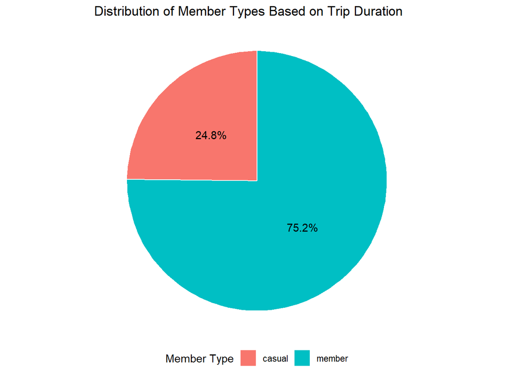

```r
# Distribution of Member Types Based on Trip Duration
my_data %>%
  count(member_casual) %>%
  mutate(Percentage = (n / sum(n)) * 100) %>%
  ggplot(aes(x = "", y = n, fill = member_casual)) +
  geom_bar(stat = "identity", width = 1, color = "white") +
  coord_polar("y", start = 0) +
  theme_void() +
  labs(title = "Distribution of Member Types Based on Trip Duration ",
       fill = "Member Type",
       x = NULL,
       y = NULL) +
  geom_text(aes(label = paste0(round(Percentage, 1), "%")),
            position = position_stack(vjust = 0.5)) +
  theme(legend.position = "bottom")
```

#### Trip duration Analysis Based On Member Type

- Compare the average trip duration between casual and member users to understand any significant differences in how long each group typically uses the bike-sharing service.

```r
trip_duration_summary <- my_data %>%
  group_by(member_casual) %>%
  summarize(
    Average = mean(trip_duration),
    Max = max(trip_duration),
    Min = min(trip_duration),
    Median = median(trip_duration),
    .groups = "keep"
  )

print(trip_duration_summary)
```

```
## # A tibble: 2 × 5
## # Groups:   member_casual [2]
##   member_casual Average   Max   Min Median
##   <chr>           <dbl> <dbl> <dbl>  <dbl>
## 1 casual           18.3  1496     1     10
## 2 member           10.6  1498     1      8
```

#### ** Day of the Week Analysis**

- Analyzed average trip duration and total trips by day of the week and member type.
- Identified patterns in member and casual rider behavior throughout the week.

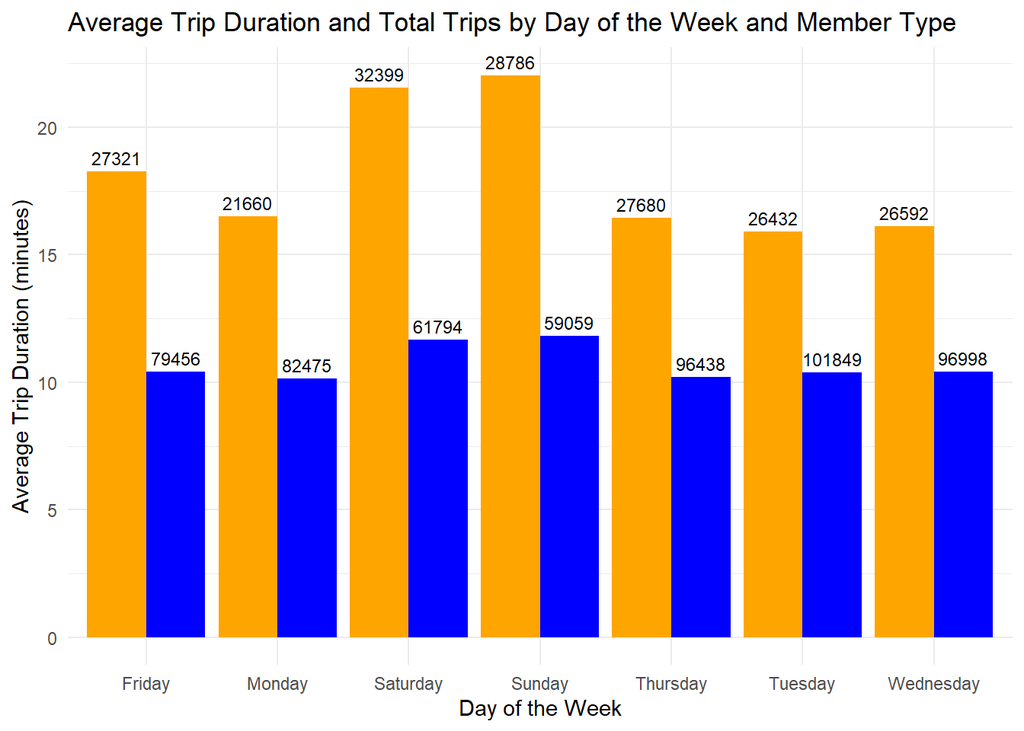

```r
# Day of the week analysis
my_data %>%
  mutate(day_of_week = weekdays(started_at)) %>%
  group_by(member_casual, day_of_week) %>%
  summarize(
    Average_Duration = mean(trip_duration),
    Total_Trips = n(),
    .groups = "keep"
  ) %>%
  ggplot(aes(x = day_of_week, y = Average_Duration, fill = member_casual, label = Total_Trips)) +
  geom_col(position = "dodge", show.legend = FALSE) +
  geom_text(position = position_dodge(width = 0.9), vjust = -0.5, size = 3, aes(label = Total_Trips)) +
  ggtitle("Average Trip Duration and Total Trips by Day of the Week and Member Type") +
  xlab("Day of the Week") +
  ylab("Average Trip Duration (minutes)") +
  scale_fill_manual(values = c("casual" = "orange", "member" = "blue")) +  # Custom colors
  theme_minimal()
```

#### **Time of Day Analysis**

- Explored average trip duration and total trips by time of day and member type.
- Noted variations in member and casual rider preferences during different times of the day.

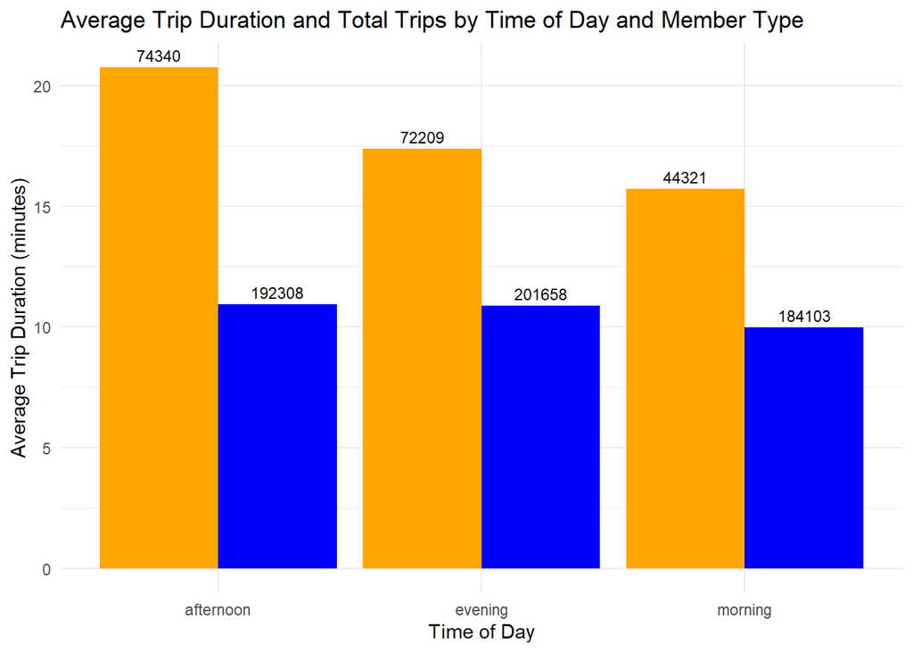

```r
# Time of day analysis based on trip duration and member type
my_data %>%
  group_by(member_casual, time_of_day) %>%
  summarize(
    Average_Duration = mean(trip_duration),
    Total_Trips = n(),
    .groups = "keep"
  ) %>%
  ggplot(aes(x = time_of_day, y = Average_Duration, fill = member_casual, label = Total_Trips)) +
  geom_col(position = "dodge", show.legend = FALSE) +
  geom_text(position = position_dodge(width = 0.9), vjust = -0.5, size = 3, aes(label = Total_Trips)) +
  ggtitle("Average Trip Duration and Total Trips by Time of Day and Member Type") +
  xlab("Time of Day") +
  ylab("Average Trip Duration (minutes)") +
  scale_fill_manual(values = c("casual" = "orange", "member" = "blue")) +  # Custom colors
  theme_minimal()
```

#### **Average Trip Duration by Trip Duration Category and Member Type**

- Examined the relationship between trip duration categories and member types.
- Identified trends in trip durations for both annual members and casual riders.

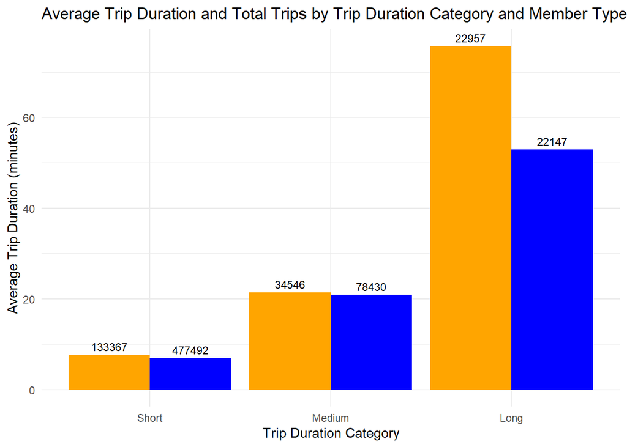

```r
# Average trip duration and total trips by trip duration and member type
my_data %>%
  group_by(member_casual, trip_duration_category) %>%
  summarize(
    Average_Duration = mean(trip_duration),
    Total_Trips = n(),
    .groups = "keep"
  ) %>%
  ggplot(aes(x = trip_duration_category, y = Average_Duration, fill = member_casual, label = Total_Trips)) +
  geom_col(position = "dodge", show.legend = FALSE) +
  geom_text(position = position_dodge(width = 0.9), vjust = -0.5, size = 3, aes(label = Total_Trips)) +
  ggtitle("Average Trip Duration and Total Trips by Trip Duration Category and Member Type") +
  xlab("Trip Duration Category") +
  ylab("Average Trip Duration (minutes)") +
  scale_fill_manual(values = c("casual" = "orange", "member" = "blue")) +  # Custom colors
  theme_minimal()
```

#### **Member Usage of Different Rideable Types**

- Investigated how member types use different rideable types based on average trip duration.
- Found insights into rideable type preferences for both annual members and casual riders.

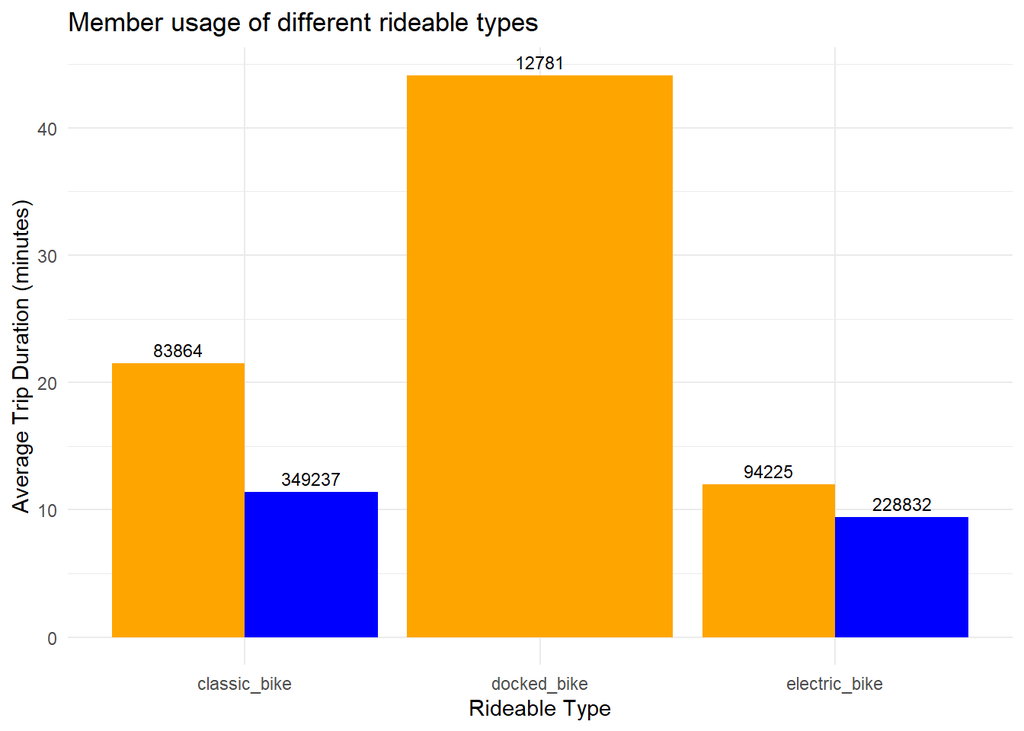

```r
# Member usage of different rideable types based on average trip duration
my_data %>%
  group_by(member_casual, rideable_type) %>%
  summarize(
    Average_Duration = mean(trip_duration),
    Total_Trips = n(),
    .groups = "keep"
  ) %>%
  ggplot(aes(x = rideable_type, y = Average_Duration, fill = member_casual, label = Total_Trips)) +
  geom_col(position = "dodge", show.legend = FALSE) +
  geom_text(position = position_dodge(width = 0.9), vjust = -0.5, size = 3, aes(label = Total_Trips)) +
  ggtitle("Member usage of different rideable types") +
  xlab("Rideable Type") +
  ylab("Average Trip Duration (minutes)") +
  scale_fill_manual(values = c("casual" = "orange", "member" = "blue")) +  # Custom colors
  theme_minimal()
```

#### **Rideable Type Preferences by Member Type**

- Explored the total trips for each rideable type, distinguishing between annual members and casual riders.
- Provided insights into the preferred rideable types for each member type.

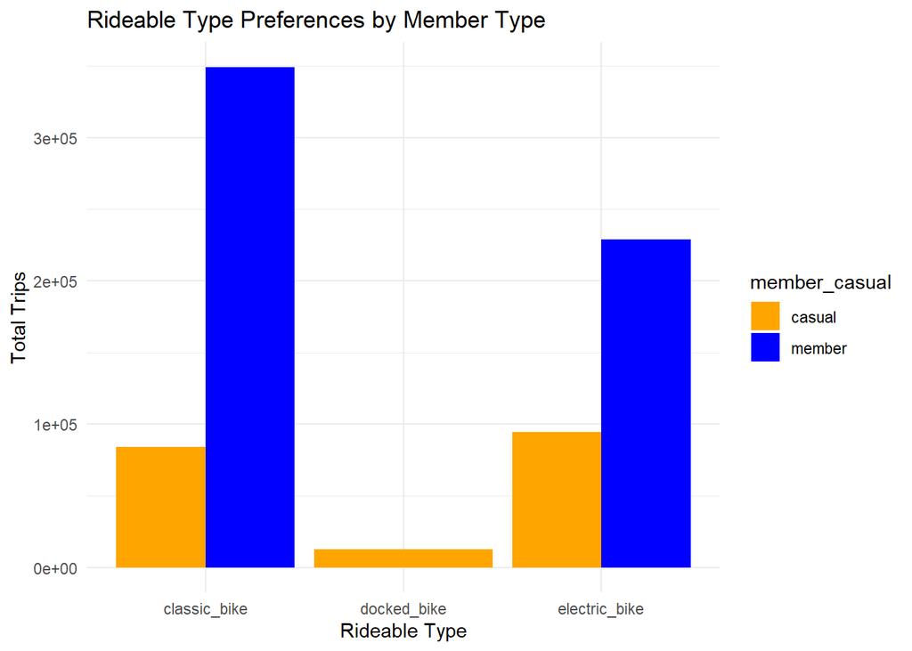

```r
# Rideable type preferences for annual members and casual riders
my_data %>%
  group_by(member_casual, rideable_type) %>%
  summarise(Total_Trips = n(),
            .groups = "keep") %>%
  ggplot(aes(x = rideable_type, y = Total_Trips, fill = member_casual)) +
  geom_bar(stat = "identity", position = "dodge") +
  ggtitle("Rideable Type Preferences by Member Type") +
  xlab("Rideable Type") +
  ylab("Total Trips") +
  scale_fill_manual(values = c("casual" = "orange", "member" = "blue")) +  # Custom colors
  theme_minimal()
```

## Recommendations

1. **Promotional Strategies:** Develop targeted promotional strategies to encourage casual riders to become annual members, focusing on the benefits of membership.
2. **Service Optimization:** Optimize bike distribution based on peak usage times, days, and rideable type preferences to enhance the overall user experience.
3. **User Engagement:** Implement features or incentives to engage users during specific times of the day or days of the week, addressing the identified patterns.

## Conclusion

To drive growth, Cyclistic should focus on converting casual riders into annual members. Tailoring marketing efforts based on usage patterns and highlighting the benefits of annual memberships can enhance user engagement and contribute to sustained success in the bike-sharing market.